# CRAN Social Network

## Sobre

A idéia aqui é mapear e construir uma rede social dos colaboradores/desenvolvedores de pacotes no CRAN e visualizar a relação entre esse desenvolvedores através de um grafo (*graph*).

No grafo, cada colaborador será um vértice, haverá uma ligação entre eles se eles colaboram em um mesmo pacote.

```r
# pacotes usados
library(tidyverse) # manipulacao de dados via dplyr, tibbles, magrittr, etc..,
```

```r
library(stringr)   # manipulacao de strings
library(igraph)    # manipulacao de grafos
library(tidygraph) # visualizacoes de redes
library(ggraph)    # visualizacoes de redes
```

Vamos puxar os dados do CRAN através da *tools::CRAN_package_db()* presente no R3.4+.

```r
# dados de publicacao de pacotes
pdb <- tools::CRAN_package_db()

# vamos obter os autors
pbaut <- pdb$Author
```

Mas o texto dos registros de autores é bem bagunçado, contendo vários autores em uma única string, é necessário fazer uma limpeza.

```r
# exemplo de um registro
pbaut[4]
```

```
## [1] "Csillery Katalin [aut],\n  Lemaire Louisiane [aut],\n  Francois Olivier [aut],\n  Blum Michael [aut, cre]"
```

```r
# manipula o vetor de autores para limpar e transformar numa lista "pacote -> [autores]"
aut <- pbaut %>%
  str_replace_all("\\(([^)]+)\\)", "") %>% # remocao
  str_replace_all("\\[([^]]+)\\]", "") %>% # remocao
  str_replace_all("<([^>]+)>", "") %>% # remocao
  str_replace_all("\n", " ") %>% # remocao
  str_replace_all("[Cc]ontribution.* from|[Cc]ontribution.* by|[Cc]ontributors", " ") %>%
  str_replace_all("\\(|\\)|\\[|\\]", " ") %>% # remocao
  iconv(to = "ASCII//TRANSLIT") %>% # limpeza dos caracters especiais
  str_replace_all("'$|^'", "") %>%  # limpeza
  gsub("([A-Z])([A-Z]{1,})", "\\1\\L\\2", ., perl = TRUE) %>%
  gsub("\\b([A-Z]{1}) \\b", "\\1\\. ", .) %>%
  map(str_split, ",|;|&| \\. |--|(?<=[a-z])\\.| [Aa]nd | [Ww]ith | [Bb]y ", simplify = TRUE) %>%
  map(str_replace_all, "[[:space:]]+", " ") %>%
  map(str_replace_all, " $|^ | \\.", "") %>%
  map(function(x) x[str_length(x) != 0]) %>%
  set_names(pdb$Package) %>%
  magrittr::extract(map_lgl(., function(x) length(x) > 1))

# conta autores por pacote
aut_list <- aut %>%
  unlist() %>%
  dplyr::as_data_frame() %>%
  count(value) %>%
  rename(Name = value, Package = n)
```

Para gerar o grafo via igraph, temos que montar uma *edge list*, uma matrix de duas colunas “conectando” as arestas.

```r
# transforma a lista "pacote" -> [autores] em uma edge list
edge_list <- aut %>%
  map(combn, m = 2) %>%    # em cada pacote (map) gera uma combinacao do array de autores dois a dois
  do.call("cbind", .) %>%
  t() %>%
  dplyr::as_data_frame() %>%
  arrange(V1, V2) %>%
  count(V1, V2)

g <- edge_list %>%
  select(V1, V2) %>%
  as.matrix() %>%
  graph.edgelist(directed = FALSE) %>%
  as_tbl_graph() %>%  # wrapper tidygraph para o objeto igraph
  activate("edges") %>% # tbl graph é duas linked table (edge e nodes) activate diz o que sera manipulado
  mutate(Weight = edge_list$n) %>% # adiciona o peso nas arestas de acordo com o numero de vezes que os autores colabora
  activate("nodes") %>%    # manipulara os nos agora
  rename(Name = name) %>% # nomeia os nos conforme
  mutate(Component = group_components()) %>%
  filter(Component == names(table(Component))[which.max(table(Component))])
```

Usando o ggraph para visulizar o graph como um tbl_graph()

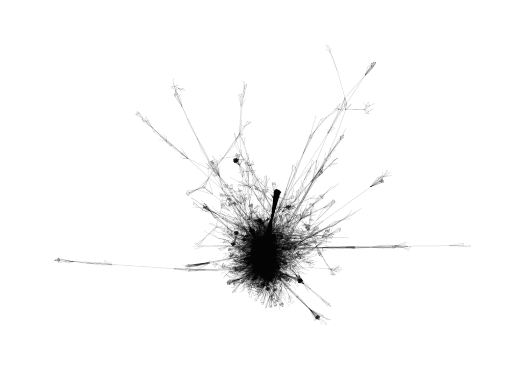

```r
ggraph(g, layout="lgl") +
  geom_edge_fan(alpha=0.1)+
  theme_graph()
```

Vamos ranquear os autores por contribuicao mais amplas (nodes que contribuem com nós que contribuem com mais nós).

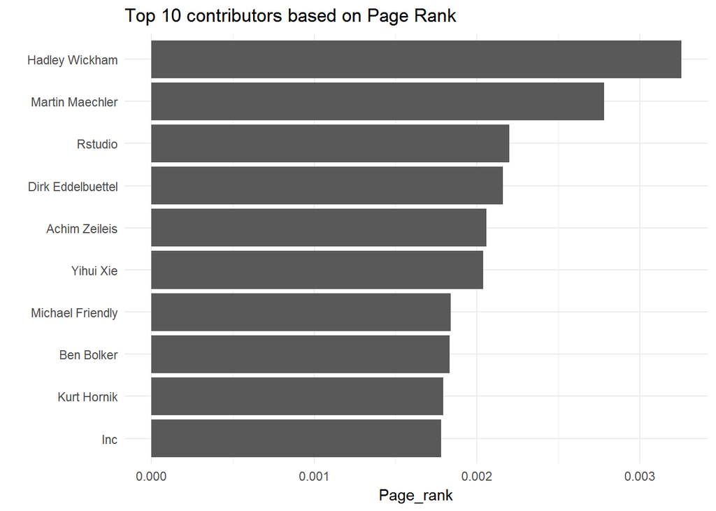

```r
g %>%
  mutate(Page_rank = centrality_pagerank()) %>%
  top_n(10, Page_rank) %>%
  as_tibble() %>%
  ggplot() +
    geom_col(aes(forcats::fct_reorder(Name, Page_rank), Page_rank)) +
    coord_flip() + theme_minimal() +
    labs(title = "Top 10 contributors based on Page Rank", x = "")
```

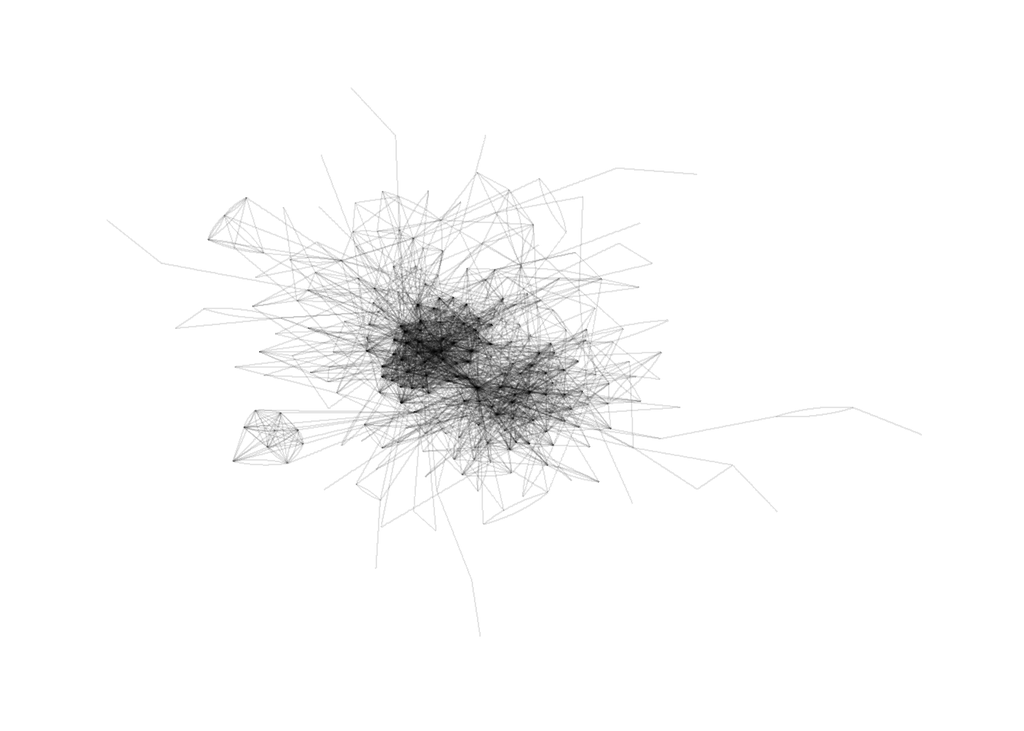

```r
g <- g %>%
  left_join(aut_list, by="Name") %>%
  filter(Package > 5) %>% # pelo menos 4 pacotes
  mutate(Component = group_components()) %>%
  filter(Component == names(table(Component))[which.max(table(Component))])

ggraph(g, layout = 'lgl') +
  geom_edge_fan(alpha = 0.1) +
  theme_graph()
```

Agora é possível ver algumas estruturas (closures) e algumas ligações entre elas (brokerage). Vamos ver se é possível identificar os autores dentro delas

```r
g <- mutate(g, Community = group_edge_betweenness(),
            Degree = centrality_degree())

filter(g, Community == names(sort(table(Community), decr = TRUE))[1]) %>%
  select(Name, Package) %>%
  arrange(desc(Package)) %>%
  top_n(10, Package) %>%
  as_tibble() %>%
  knitr::kable(format = "html", caption = "Cluster 1")
```

Cluster 1

| Name | Package |
| --- | --- |
| Kurt Hornik | 56 |
| Martin Maechler | 46 |
| Achim Zeileis | 45 |
| Dirk Eddelbuettel | 43 |
| Romain Francois | 28 |
| Ben Bolker | 25 |
| Brian Ripley | 25 |
| Torsten Hothorn | 24 |
| Douglas Bates | 24 |
| Roger Bivand | 23 |

```r
filter(g, Community == names(sort(table(Community), decr = TRUE))[2]) %>%
  select(Name, Package) %>%
  arrange(desc(Package)) %>%
  top_n(10, Package) %>%
  as_tibble() %>%
  knitr::kable(format = "html", caption = "Cluster 2")
```

Cluster 2

| Name | Package |
| --- | --- |
| Rstudio | 96 |
| Hadley Wickham | 96 |
| Scott Chamberlain | 45 |
| Inc | 38 |
| Yihui Xie | 34 |
| Jeroen Ooms | 34 |
| Jj Allaire | 29 |
| R. Core Team | 28 |
| Bob Rudis | 27 |
| Oliver Keyes | 22 |
| Winston Chang | 22 |

Os autores dos dois grupos se destacam, alguns do primeiro mantém o RBase e outros pacotes de infraestrutura tadicional, os do cluster 2, mantém pacotes mais novos, como o dplyr, xgboost, etc.

Vamos colorir os clusters

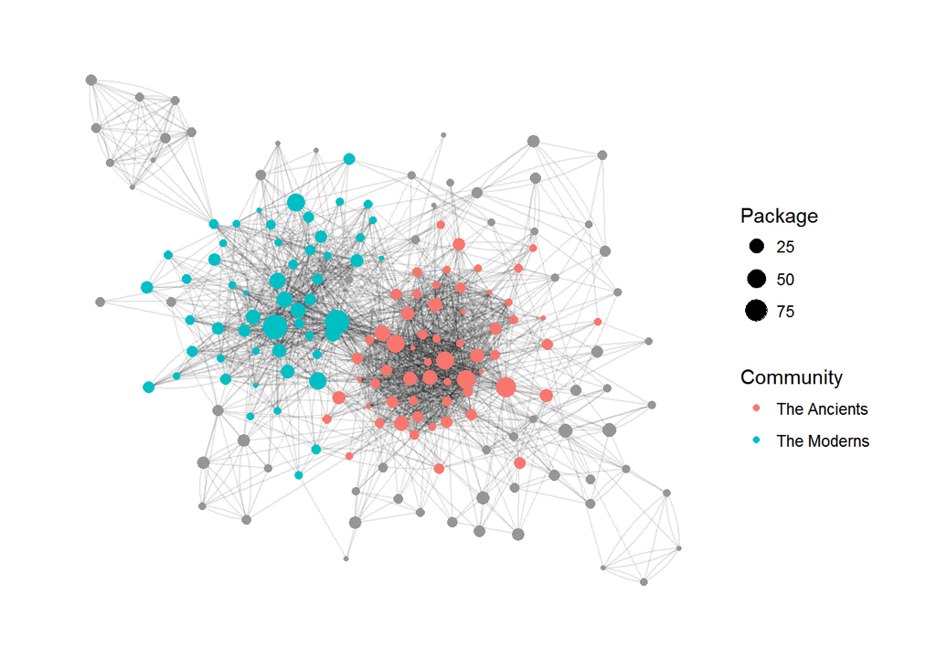

```r
g <- g %>%
  mutate(Community = case_when(Community == names(sort(table(Community),
                                                       decr = TRUE))[1] ~ "The Ancients",
                               Community == names(sort(table(Community),
                                                       decr = TRUE))[2] ~ "The Moderns",
                               Community %in% names(sort(table(Community),
                                                       decr = TRUE))[-1:-2] ~ "Unclassified")) %>%
  mutate(Community = factor(Community))

g <- g %>%
  filter(Degree > 5) %>%
  mutate(Degree = centrality_degree())

ggraph(g, layout = 'lgl') +
  geom_edge_fan(alpha = 0.1) +
  geom_node_point(aes(color = Community, size = Package)) +
  theme_graph() +
  scale_color_manual(breaks = c("The Ancients", "The Moderns"),
                     values=c("#F8766D", "#00BFC4", "#969696"))
```

Contando os pacotes que conectam autores de comunidades distintas

```r
g %>% activate("edges") %>%
  mutate(Community_from = .N()$Community[from],
         Community_to = .N()$Community[to]) %>%
  filter((Community_from == "The Ancients" & Community_to == "The Moderns")|
           Community_from == "The Moderns" & Community_to == "The Ancients") %>%
  as_tibble() %>%
  nrow()
```

```
## [1] 209
```